# Contact Experiment Data Analysis

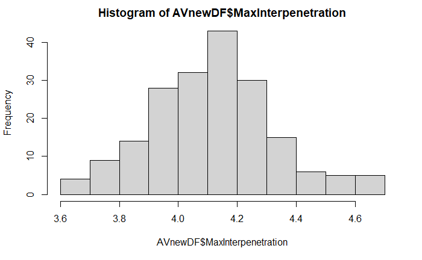

```r
# We still have a problem with distribution


#Try by converting the DVs into logarithms again
AVnewDF$MaxInterpenetration <- log10(AVnewDF$MaxInterpenetration)

AVnewDF$AverageInterpenetration <- log10(AVnewDF$AverageInterpenetration)


hist(AVnewDF$MaxInterpenetration)
```

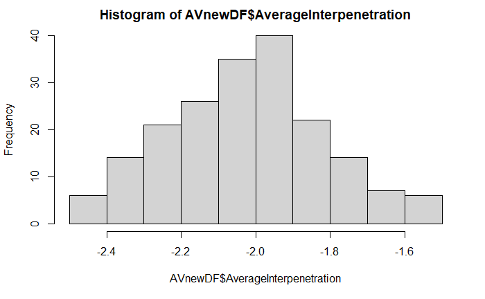

```r
hist(AVnewDF$AverageInterpenetration)
```

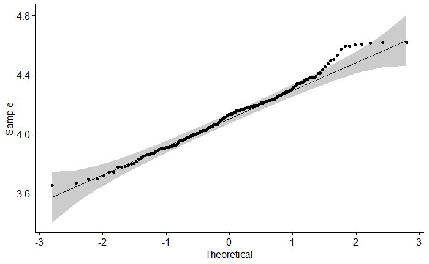

```r
ggqqplot(AVnewDF$MaxInterpenetration)
```

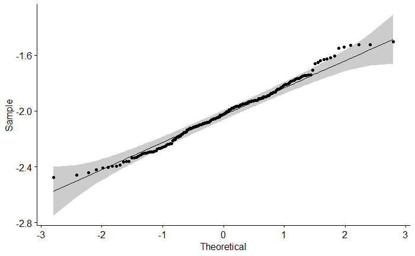

```r
ggqqplot(AVnewDF$AverageInterpenetration)
```

```r
shapiro_test(AVnewDF$MaxInterpenetration)
```

| variable | statistic | p.value |
| --- | --- | --- |
| AVnewDF$MaxInterpenetration | 0.9868206 | 0.07213808 |

```r
shapiro_test(AVnewDF$AverageInterpenetration)
```

| variable | statistic | p.value |
| --- | --- | --- |
| AVnewDF$AverageInterpenetration | 0.9883614 | 0.120067 |

```r
AVnewDF %>%
  group_by(InterpenetrationFeedback, FullyShaded) %>%
  shapiro_test(MaxInterpenetration)
```

| InterpenetrationFeedback | FullyShaded | variable | statistic | p |
| --- | --- | --- | --- | --- |
| Both | FALSE | MaxInterpenetration | 0.9271168 | 0.08405471 |
| Both | TRUE | MaxInterpenetration | 0.9525789 | 0.30784280 |
| Electrotactile | FALSE | MaxInterpenetration | 0.9339132 | 0.11925613 |
| Electrotactile | TRUE | MaxInterpenetration | 0.9726355 | 0.73207234 |
| NoFeedback | FALSE | MaxInterpenetration | 0.9912405 | 0.99863382 |
| NoFeedback | TRUE | MaxInterpenetration | 0.9675696 | 0.60748593 |
| Visual | FALSE | MaxInterpenetration | 0.9320320 | 0.10824009 |
| Visual | TRUE | MaxInterpenetration | 0.9749502 | 0.78793997 |

```r
AVnewDF %>%
  group_by(InterpenetrationFeedback, FullyShaded) %>%
  shapiro_test(AverageInterpenetration)
```

| InterpenetrationFeedback | FullyShaded | variable | statistic | p |
| --- | --- | --- | --- | --- |
| Both | FALSE | AverageInterpenetration | 0.9548612 | 0.3440624 |
| Both | TRUE | AverageInterpenetration | 0.9564079 | 0.3705815 |
| Electrotactile | FALSE | AverageInterpenetration | 0.9608071 | 0.4548534 |
| Electrotactile | TRUE | AverageInterpenetration | 0.9694007 | 0.6522046 |
| NoFeedback | FALSE | AverageInterpenetration | 0.9678243 | 0.6370800 |
| NoFeedback | TRUE | AverageInterpenetration | 0.9899268 | 0.9960554 |
| Visual | FALSE | AverageInterpenetration | 0.9453427 | 0.2143148 |
| Visual | TRUE | AverageInterpenetration | 0.9651151 | 0.5493487 |

```r
############### PERFECT WE ARE GOOD TO GO !!!!!!!!!!!!!!!!!!!!!
```

Lets do the box-violin plots again

```r
p1 <- ggstatsplot::ggbetweenstats(
  data = AVnewDF,
  x = "InterpenetrationFeedback", #Indepedent Variable
  y = "MaxInterpenetration", # Depedent Variable
  grouping.var = "FullyShaded", # 2nd IV
  type = "p", # parametric test i.e., p values
  pairwise.comparisons = TRUE, #compute pairwise comparisons
  pairwise.display = "significant",
  p.adjust.method = "bonferroni", # correction of p-value
  effsize.type = "unbiased", # Calculates the Hedge's g for t tests and the partial Omega for ANOVA
  xlab = "Type of Feedback", #label of X axis
  ylab = "Maximum Interpenetration", #label of y axis
  var.equal = TRUE, #Assuming Equal variances
  mean.ci = TRUE, #display the confidence interval of the mean
  notch = TRUE, #Compare the medians i.e., IQR with 95% confidence interval
  paired = TRUE #indicating that we have a within subject design
  )

p2 <- ggstatsplot::ggbetweenstats(
  data = AVnewDF,
  x = "InterpenetrationFeedback",
  y = "AverageInterpenetration",
  grouping.var = "FullyShaded",
  type = "p",
  pairwise.comparisons = TRUE,
  pairwise.display = "significant",
  p.adjust.method = "bonferroni",
  effsize.type = "unbiased",
  xlab = "Type of Feedback",
  ylab = "Average Interpenetration",
  var.equal = TRUE,
  mean.ci = TRUE,
  notch = TRUE,
  paired = TRUE
)


# Replicating the above but this time we look on the effect of the type of feedback on the DVs when the shaded is true and when it is false.
p3 <- ggstatsplot::grouped_ggbetweenstats(
  data = AVnewDF,
  x = "InterpenetrationFeedback",
  y = "MaxInterpenetration",
  grouping.var = "FullyShaded",
  type = "p",
  pairwise.comparisons = TRUE,
  pairwise.display = "significant",
  p.adjust.method = "bonferroni",
  effsize.type = "unbiased",
  xlab = "Type of Feedback",
  ylab = "Maximum Interpenetration",
  sub.text = "Explicit Visual Representation" ,
  var.equal = TRUE,
  mean.ci = TRUE,
  notch = TRUE,
  paired = TRUE
  )
```

```
notch went outside hinges. Try setting notch=FALSE.
```

```r
p4 <- ggstatsplot::grouped_ggbetweenstats(
  data = AVnewDF,
  x = "InterpenetrationFeedback",
  y = "AverageInterpenetration",
  grouping.var = "FullyShaded",
  type = "p",
  pairwise.comparisons = TRUE,
  pairwise.display = "significant",
  p.adjust.method = "bonferroni",
  effsize.type = "unbiased",
  xlab = "Type of Feedback",
  ylab = "Average Interpenetration",
  var.equal = TRUE,
  mean.ci = TRUE,
  notch = TRUE,
  paired = TRUE
)
```

```
notch went outside hinges. Try setting notch=FALSE.
```

```r
# Lets check the effect of shaded condition on DVs
p5 <- ggstatsplot:: ggbetweenstats(
  data = AVnewDF,
  x = "FullyShaded",
  y = "MaxInterpenetration",
  grouping.var = "InterpenetrationFeedback",
  type = "p",
  pairwise.comparisons = TRUE,
  pairwise.display = "significant",
  p.adjust.method = "bonferroni",
  effsize.type = "unbiased",
  xlab = "Target's Visual Representation",
  ylab = "Maximum Interpenetration",
  sub.text = "Explicit Visual Representation" ,
  var.equal = TRUE,
  mean.ci = TRUE,
  notch = TRUE,
  paired = TRUE
  )

p6 <- ggstatsplot::ggbetweenstats(
  data = AVnewDF,
  x = "FullyShaded",
  y = "AverageInterpenetration",
  grouping.var = "InterpenetrationFeedback",
  type = "p",
  pairwise.comparisons = TRUE,
  pairwise.display = "significant",
  p.adjust.method = "bonferroni",
  effsize.type = "unbiased",
  xlab = "Target's Visual Representation",
  ylab = "Average Interpenetration",
  var.equal = TRUE,
  mean.ci = TRUE,
  notch = TRUE,
  paired = TRUE
)

p7 <- ggstatsplot::grouped_ggbetweenstats(
  data = AVnewDF,
  x = "FullyShaded",
  y = "MaxInterpenetration",
  grouping.var = "InterpenetrationFeedback",
  type = "p",
  pairwise.comparisons = TRUE,
  pairwise.display = "significant",
  p.adjust.method = "bonferroni",
  effsize.type = "unbiased",
  xlab = "Target's Visual Representation",
  ylab = "Maximum Interpenetration",
  sub.text = "Explicit Visual Representation" ,
  var.equal = TRUE,
  mean.ci = TRUE,
  notch = TRUE,
  paired = TRUE
  )
```

```
notch went outside hinges. Try setting notch=FALSE.
```

```r
p8 <- ggstatsplot::grouped_ggbetweenstats(
  data = AVnewDF,
  x = "FullyShaded",
  y = "AverageInterpenetration",
  grouping.var = "InterpenetrationFeedback",
  type = "p",
  pairwise.comparisons = TRUE,
  pairwise.display = "significant",
  p.adjust.method = "bonferroni",
  effsize.type = "unbiased",
  xlab = "Target's Visual Representation",
  ylab = "Average Interpenetration",
  var.equal = TRUE,
  mean.ci = TRUE,
  notch = TRUE,
  paired = TRUE
)
```

```
notch went outside hinges. Try setting notch=FALSE.
```

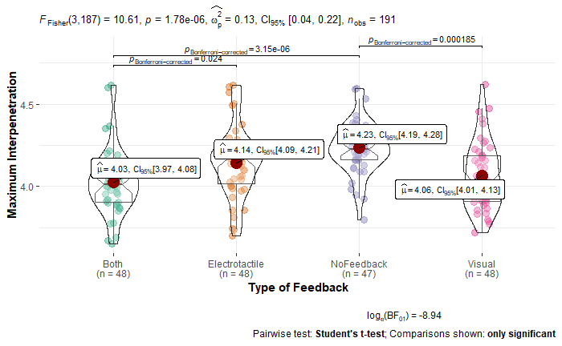

```r
p1
```

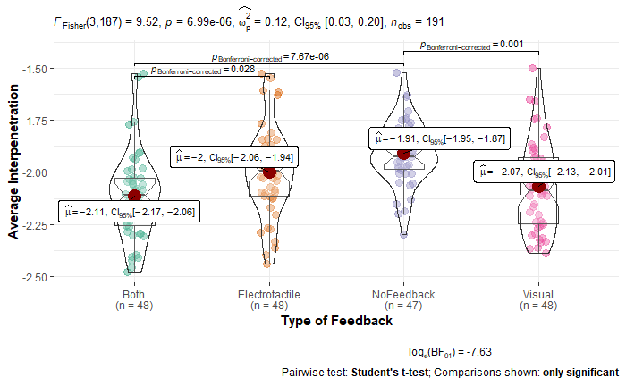

```r
p2
```

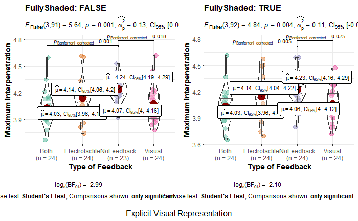

```r
p3
```

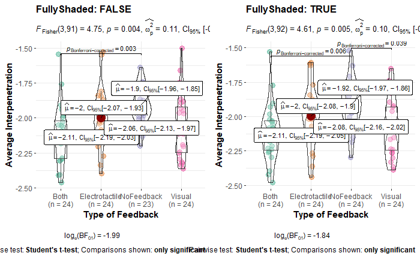

```r
p4
```

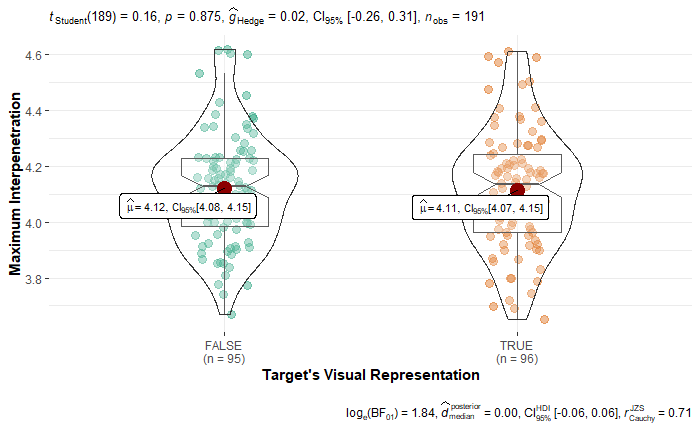

```r
p5
```

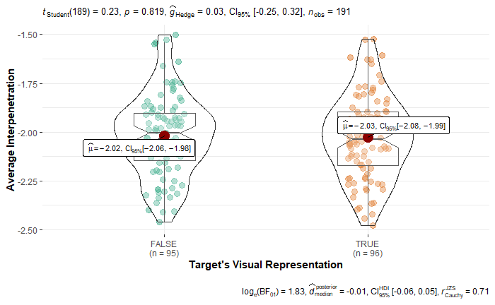

```r
p6
```

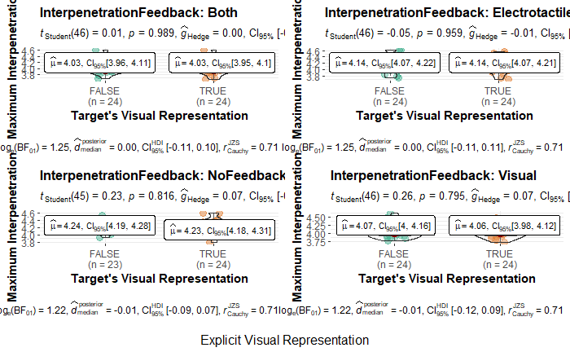

```r
p7
```

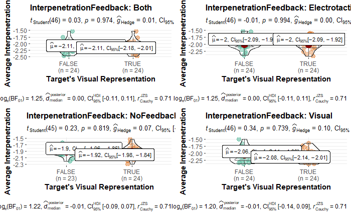

```r
p8
```

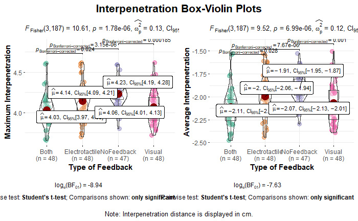

```r
plist <- list(p1,p2)
plist2 <- list(p3,p4)
plist3 <- list(p5,p6)
plist4 <- list(p7,p8)

combine_plots(
  plotlist = plist,
  title.text = "Interpenetration Box-Violin Plots",
  caption.text = "Note: Interpenetration distance is displayed in cm.",
  title.color = "black",
  caption.color = "black")
```

[figure not shown]

```r
combine_plots(
  plotlist = plist2,
  title.text = "Interpenetration Box-Violin Plots",
  caption.text = "Note: Interpenetration distance is displayed in cm.",
  title.color = "black",
  caption.color = "black")
```

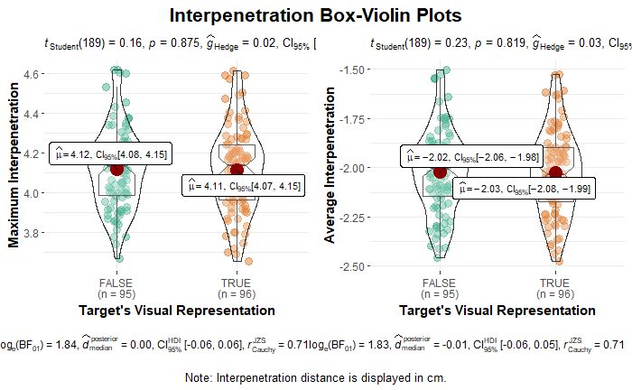

```r
combine_plots(
  plotlist = plist3,
  title.text = "Interpenetration Box-Violin Plots",
  caption.text = "Note: Interpenetration distance is displayed in cm.",
  title.color = "black",
  caption.color = "black")
```

[figure not shown]

```r
combine_plots(
  plotlist = plist4,
  title.text = "Interpenetration Box-Violin Plots",
  caption.text = "Note: Interpenetration distance is displayed in cm.",
  title.color = "black",
  caption.color = "black")
```

The bad news are that now we do not have an effect between electrotactile and No Feedback conditions

Also, there is a significant difference between Both and Electrotactile Feedback.

The rest remain as we interpreted above for the plots using the df_clean2

```r
TwoWayAnovaRM_Max <- anova_test(
  data = AVnewDF, dv = MaxInterpenetration, wid = ID,
  formula = MaxInterpenetration ~  InterpenetrationFeedback*FullyShaded + (1|ID),
  within = c(InterpenetrationFeedback, FullyShaded)
  )
```

```
Coefficient covariances computed by hccm()
Note: model has aliased coefficients
      sums of squares computed by model comparison
```

```r
get_anova_table(TwoWayAnovaRM_Max )
```

```
ANOVA Table (type II tests)

                                Effect DFn DFd      F        p p<.05      ges
1             InterpenetrationFeedback   3 183 10.395 2.38e-06     * 0.146000
2                          FullyShaded   1 183  0.045 8.33e-01       0.000244
3                               1 | ID   0 183     NA       NA  <NA>       NA
4 InterpenetrationFeedback:FullyShaded   3 183  0.024 9.95e-01       0.000386
```

```r
TwoWayAnovaRM_Av <- anova_test(
  data = AVnewDF, dv = AverageInterpenetration, wid = ID,
  formula = AverageInterpenetration ~  InterpenetrationFeedback*FullyShaded + (1|ID),
  within = c(InterpenetrationFeedback, FullyShaded)
  )
```

```
Coefficient covariances computed by hccm()
Note: model has aliased coefficients
      sums of squares computed by model comparison
```

```r
get_anova_table(TwoWayAnovaRM_Av)
```

```
ANOVA Table (type II tests)

                                Effect DFn DFd     F        p p<.05      ges
1             InterpenetrationFeedback   3 183 9.330 9.02e-06     * 0.133000
2                          FullyShaded   1 183 0.080 7.78e-01       0.000437
3                               1 | ID   0 183    NA       NA  <NA>       NA
4 InterpenetrationFeedback:FullyShaded   3 183 0.028 9.94e-01       0.000459
```

So, again there is no effect of the Fully Shade neither on DVs nor an interrelationship with Int feedback

So we go for OneWay Repeated Measures ANOVA

```r
OneWayAnovaRM_Max <- anova_test(
  data = AVnewDF, dv = MaxInterpenetration, wid = ID,
  formula = MaxInterpenetration ~  InterpenetrationFeedback + (1|ID)
  )
```

```
Coefficient covariances computed by hccm()
Note: model has aliased coefficients
      sums of squares computed by model comparison
```

```r
get_anova_table(OneWayAnovaRM_Max )
```

```
ANOVA Table (type II tests)

                    Effect DFn DFd     F        p p<.05   ges
1 InterpenetrationFeedback   3 187 10.61 1.78e-06     * 0.145
2                   1 | ID   0 187    NA       NA  <NA>    NA
```

```r
OneWayAnovaRM_Av <- anova_test(
  data = AVnewDF, dv = AverageInterpenetration, wid = ID,
  formula = AverageInterpenetration ~  InterpenetrationFeedback + (1|ID)
  )
```

```
Coefficient covariances computed by hccm()
Note: model has aliased coefficients
      sums of squares computed by model comparison
```

```r
get_anova_table(OneWayAnovaRM_Av)
```

```
ANOVA Table (type II tests)

                    Effect DFn DFd     F        p p<.05   ges
1 InterpenetrationFeedback   3 187 9.518 6.99e-06     * 0.132
2                   1 | ID   0 187    NA       NA  <NA>    NA
```

So, we have significant effect of the IV on the DV

So, we may now go for post hoc tests

```
    Pairwise comparisons using t tests with pooled SD

data:  AVnewDF$MaxInterpenetration and AVnewDF$InterpenetrationFeedback

               Both    Electrotactile NoFeedback
Electrotactile 0.02397 -              -
NoFeedback     3.2e-06 0.13584        -
Visual         1.00000 0.29208        0.00018

P value adjustment method: bonferroni

    Pairwise comparisons using t tests with pooled SD

data:  AVnewDF$AverageInterpenetration and AVnewDF$InterpenetrationFeedback

               Both    Electrotactile NoFeedback
Electrotactile 0.02763 -              -
NoFeedback     7.7e-06 0.19555        -
Visual         1.00000 0.50426        0.00086

P value adjustment method: bonferroni
```

Let’s check the difference between 1st and 2nd part

```r
# needed for ANOVA functions.
library("afex")

newDF$Part <- as.factor(newDF$Block < 4)

levels(newDF$Part)
```

```
[1] "FALSE" "TRUE"
```

```r
newDF$Part <- factor(newDF$Part,levels = c("TRUE","FALSE"),
                  labels = c("Part 1","Part 2"))


newDF_Parts <- aggregate(. ~ ID + Age + Gender + InterpenetrationFeedback + Part, newDF, mean)
```

```r
?aov_ez()
a1 <- aov_ez("ID", "MaxInterpenetration", newDF_Parts,
             within = c("Part", "InterpenetrationFeedback"),
             anova_table = list(es = "pes"))
```

```
Missing values for following ID(s):
9, 17
Removing those cases from the analysis.
```

```r
knitr::kable(nice(a1$anova_table))
```

| Effect | df | MSE | F | pes | p.value |
| --- | --- | --- | --- | --- | --- |
| Part | 1, 21 | 0.00 | 19.57 *** | .482 | <.001 |
| InterpenetrationFeedback | 2.23, 46.77 | 0.00 | 18.49 *** | .468 | <.001 |
| Part:InterpenetrationFeedback | 1.80, 37.81 | 0.00 | 3.35 + | .138 | .051 |

```r
a2 <- aov_ez("ID", "AverageInterpenetration", newDF_Parts,
             within = c("Part", "InterpenetrationFeedback"),
             anova_table = list(es = "pes"))
```

```
Missing values for following ID(s):
9, 17
Removing those cases from the analysis.
```

```r
knitr::kable(nice(a2$anova_table))
```

| Effect | df | MSE | F | pes | p.value |
| --- | --- | --- | --- | --- | --- |
| Part | 1, 21 | 0.00 | 23.00 *** | .523 | <.001 |
| InterpenetrationFeedback | 2.27, 47.61 | 0.00 | 19.44 *** | .481 | <.001 |
| Part:InterpenetrationFeedback | 2.19, 45.93 | 0.00 | 3.51 * | .143 | .034 |

```r
NA
```

```r
effectsize::omega_squared(a1, partial = TRUE, ci = 0.95)
```

```
Parameter                     | Omega2 (partial) |        95% CI
----------------------------------------------------------------
Part                          |             0.45 | [ 0.12, 0.66]
InterpenetrationFeedback      |             0.44 | [ 0.24, 0.57]
Part:InterpenetrationFeedback |             0.10 | [-0.05, 0.24]
```

Reference for interpreting Omega Squared Small effect: ω2 = 0.01; Medium effect: ω2 = 0.06; Large effect: ω2 = 0.14.

```r
effectsize::omega_squared(a2, partial = TRUE, ci = 0.95)
```

```
Parameter                     | Omega2 (partial) |        95% CI
----------------------------------------------------------------
Part                          |             0.49 | [ 0.16, 0.69]
InterpenetrationFeedback      |             0.45 | [ 0.25, 0.59]
Part:InterpenetrationFeedback |             0.10 | [-0.04, 0.25]
```

Reference for interpreting Omega Squared Small effect: ω2 = 0.01; Medium effect: ω2 = 0.06; Large effect: ω2 = 0.14.

```r
pw1 <- pairwise.t.test(newDF_Parts$AverageInterpenetration, newDF_Parts$InterpenetrationFeedback, p.adjust.method = "bonferroni",
        paired = FALSE, alternative = "two.sided")

pw1
```

```
    Pairwise comparisons using t tests with pooled SD

data:  newDF_Parts$AverageInterpenetration and newDF_Parts$InterpenetrationFeedback

               Both   Electrotactile NoFeedback
Electrotactile 0.0731 -              -
NoFeedback     0.0039 1.0000         -
Visual         1.0000 0.6397         0.0661

P value adjustment method: bonferroni
```

```r
effectsize::hedges_g("AverageInterpenetration", "Part", data = newDF_Parts, correction = TRUE, paired = TRUE)
```

```
Hedge's g |       95% CI
------------------------
     0.50 | [0.29, 0.71]
```

```r
is.factor(newDF_Parts$InterpenetrationFeedback)
```

```
[1] TRUE
```

```r
levels(newDF_Parts$InterpenetrationFeedback)
```

```
[1] "Both"           "Electrotactile" "NoFeedback"     "Visual"
```

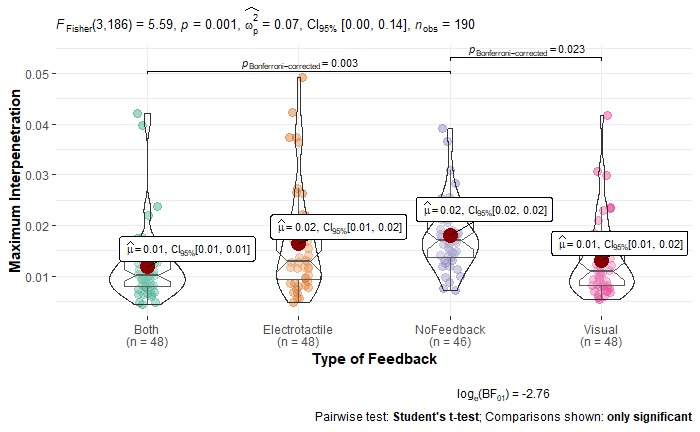

```r
p1 <- ggstatsplot::ggbetweenstats(
  data = newDF_Parts,
  x = "InterpenetrationFeedback", #Indepedent Variable
  y = "MaxInterpenetration", # Depedent Variable
  grouping.var = "Part", # 2nd IV
  type = "p", # parametric test i.e., p values
  pairwise.comparisons = TRUE, #compute pairwise comparisons
  pairwise.display = "significant",
  p.adjust.method = "bonferroni", # correction of p-value
  effsize.type = "unbiased", # Calculates the Hedge's g for t tests and the partial Omega for ANOVA
  xlab = "Type of Feedback", #label of X axis
  ylab = "Maximum Interpenetration", #label of y axis
  var.equal = TRUE, #Assuming Equal variances
  mean.ci = TRUE, #display the confidence interval of the mean
  notch = TRUE, #Compare the medians i.e., IQR with 95% confidence interval
  paired = TRUE #indicating that we have a within subject design
  )

p2 <- ggstatsplot::ggbetweenstats(
  data = newDF_Parts,
  x = "InterpenetrationFeedback",
  y = "AverageInterpenetration",
  grouping.var = "Part",
  type = "p",
  pairwise.comparisons = TRUE,
  pairwise.display = "significant",
  p.adjust.method = "bonferroni",
  effsize.type = "unbiased",
  xlab = "Type of Feedback",
  ylab = "Average Interpenetration",
  var.equal = TRUE,
  mean.ci = TRUE,
  notch = TRUE,
  paired = TRUE
)


# Replicating the above but this time we look on the effect of the type of feedback on the DVs when the shaded is true and when it is false.
p3 <- ggstatsplot::grouped_ggbetweenstats(
  data = newDF_Parts,
  x = "InterpenetrationFeedback",
  y = "MaxInterpenetration",
  grouping.var = "Part",
  type = "p",
  pairwise.comparisons = TRUE,
  pairwise.display = "significant",
  p.adjust.method = "bonferroni",
  effsize.type = "unbiased",
  xlab = "Type of Feedback",
  ylab = "Maximum Interpenetration",
  sub.text = "Explicit Visual Representation" ,
  var.equal = TRUE,
  mean.ci = TRUE,
  notch = TRUE,
  paired = TRUE
  )

p4 <- ggstatsplot::grouped_ggbetweenstats(
  data = newDF_Parts,
  x = "InterpenetrationFeedback",
  y = "AverageInterpenetration",
  grouping.var = "Part",
  type = "p",
  pairwise.comparisons = TRUE,
  pairwise.display = "significant",
  p.adjust.method = "bonferroni",
  effsize.type = "unbiased",
  xlab = "Type of Feedback",
  ylab = "Average Interpenetration",
  var.equal = TRUE,
  mean.ci = TRUE,
  notch = TRUE,
  paired = TRUE
)

# Lets check the effect of shaded condition on DVs
p5 <- ggstatsplot:: ggbetweenstats(
  data = newDF_Parts,
  x = "Part",
  y = "MaxInterpenetration",
  grouping.var = "InterpenetrationFeedback",
  type = "p",
  pairwise.comparisons = TRUE,
  pairwise.display = "significant",
  p.adjust.method = "bonferroni",
  effsize.type = "unbiased",
  xlab = "Target's Visual Representation",
  ylab = "Maximum Interpenetration",
  sub.text = "Explicit Visual Representation" ,
  var.equal = TRUE,
  mean.ci = TRUE,
  notch = TRUE,
  paired = TRUE
  )

p6 <- ggstatsplot::ggbetweenstats(
  data = newDF_Parts,
  x = "Part",
  y = "AverageInterpenetration",
  grouping.var = "InterpenetrationFeedback",
  type = "p",
  pairwise.comparisons = TRUE,
  pairwise.display = "significant",
  p.adjust.method = "bonferroni",
  effsize.type = "unbiased",
  xlab = "Target's Visual Representation",
  ylab = "Average Interpenetration",
  var.equal = TRUE,
  mean.ci = TRUE,
  notch = TRUE,
  paired = TRUE
)

p7 <- ggstatsplot::grouped_ggbetweenstats(
  data = newDF_Parts,
  x = "Part",
  y = "MaxInterpenetration",
  grouping.var = "InterpenetrationFeedback",
  type = "p",
  pairwise.comparisons = TRUE,
  pairwise.display = "significant",
  p.adjust.method = "bonferroni",
  effsize.type = "unbiased",
  xlab = "Target's Visual Representation",
  ylab = "Maximum Interpenetration",
  sub.text = "Explicit Visual Representation" ,
  var.equal = TRUE,
  mean.ci = TRUE,
  notch = TRUE,
  paired = TRUE
  )

p8 <- ggstatsplot::grouped_ggbetweenstats(
  data = newDF_Parts,
  x = "Part",
  y = "AverageInterpenetration",
  grouping.var = "InterpenetrationFeedback",
  type = "p",
  pairwise.comparisons = TRUE,
  pairwise.display = "significant",
  p.adjust.method = "bonferroni",
  effsize.type = "unbiased",
  xlab = "Target's Visual Representation",
  ylab = "Average Interpenetration",
  var.equal = TRUE,
  mean.ci = TRUE,
  notch = TRUE,
  paired = TRUE
)
p1
```

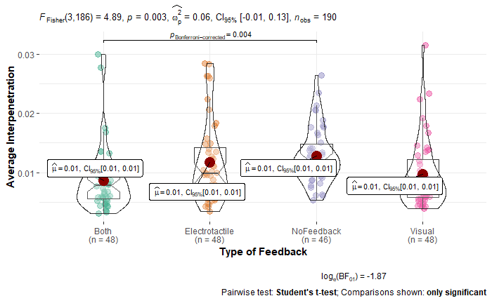

```r
p2
```

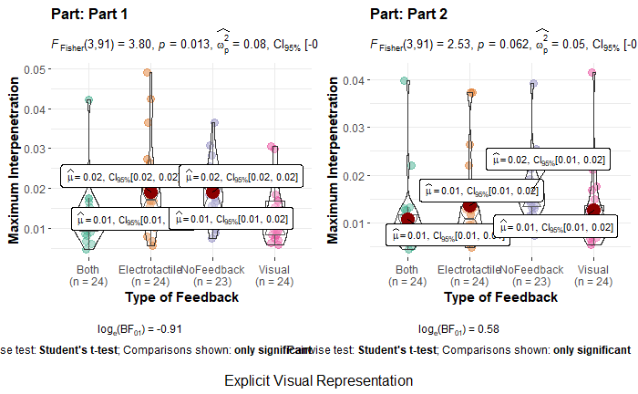

```r
p3
```

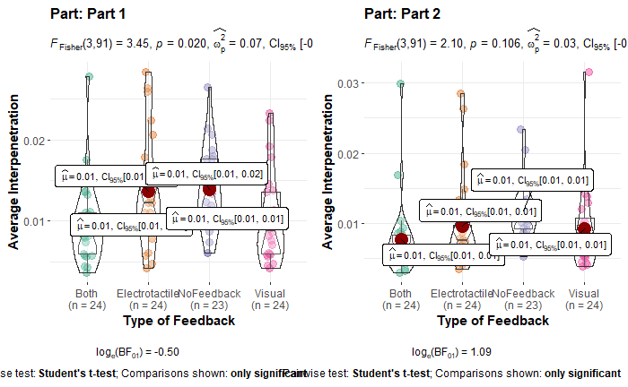

```r
p4
```

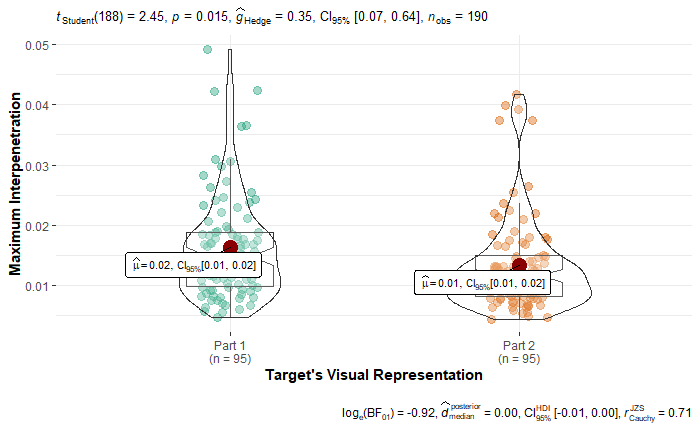

```r
p5
```

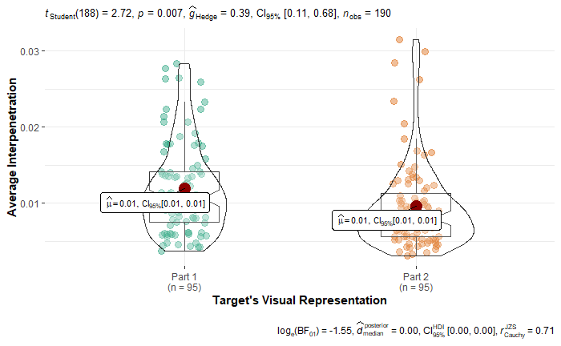

```r
p6
```

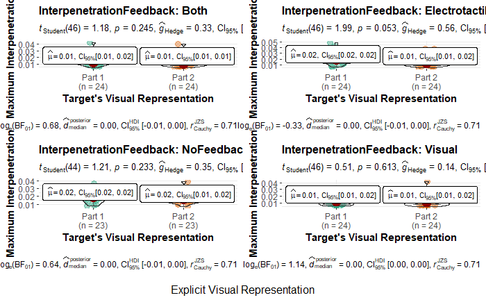

```r
p7
```

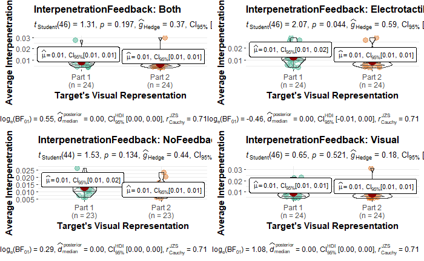

```r
p8
```

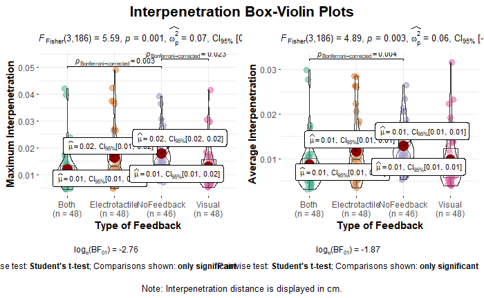

```r
plist <- list(p1,p2)
plist2 <- list(p3,p4)
plist3 <- list(p5,p6)
plist4 <- list(p7,p8)

combine_plots(
  plotlist = plist,
  title.text = "Interpenetration Box-Violin Plots",
  caption.text = "Note: Interpenetration distance is displayed in cm.",
  title.color = "black",
  caption.color = "black")
```

[figure not shown]

```r
combine_plots(
  plotlist = plist2,
  title.text = "Interpenetration Box-Violin Plots",
  caption.text = "Note: Interpenetration distance is displayed in cm.",
  title.color = "black",
  caption.color = "black")
```

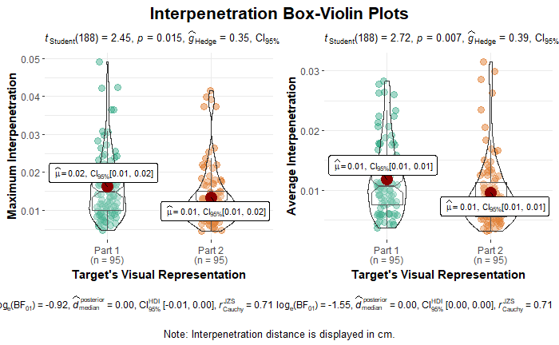

```r
combine_plots(
  plotlist = plist3,
  title.text = "Interpenetration Box-Violin Plots",
  caption.text = "Note: Interpenetration distance is displayed in cm.",
  title.color = "black",
  caption.color = "black")
```

[figure not shown]

```r
combine_plots(
  plotlist = plist4,
  title.text = "Interpenetration Box-Violin Plots",
  caption.text = "Note: Interpenetration distance is displayed in cm.",
  title.color = "black",
  caption.color = "black")
```

```r
NA
NA
```

Parsimonious Approach;: Without the IDs which produced Extreme Values

Now lets do all again but this time without the IDs which produced the Extreme Values

```r
ParsiDF <- NewData

ParsiDF$Part <- as.factor(ParsiDF$Block < 4)
levels(ParsiDF$Part)
```

```
[1] "FALSE" "TRUE"
```

```r
ParsiDF$Part <- factor(ParsiDF$Part,levels = c("TRUE","FALSE"),
                  labels = c("Part 1","Part 2"))

ParsiDF$Extreme1 <- is_extreme(ParsiDF$MaxInterpenetration)

ParsiDF$Extreme2 <- is_extreme(ParsiDF$AverageInterpenetration)
#ParsiDF$Extreme1[ParsiDF$Extreme1 == TRUE]  <- NA
#ParsiDF$Extreme2[ParsiDF$Extreme2 == TRUE]  <- NA

ParsiDF$ID[ParsiDF$ID == 9] <- NA
ParsiDF$ID[ParsiDF$ID == 17] <- NA
ParsiDF$ID[ParsiDF$ID == 20] <- NA

ParsiDF <- na.omit(ParsiDF)

#ParsiDF$Part <- as.factor(ParsiDF$Block < 4)



ParsiDF <- aggregate(. ~ ID + Age + Gender + InterpenetrationFeedback + Part, ParsiDF, mean)

shapiro_test(ParsiDF$MaxInterpenetration)
```

| variable | statistic | p.value |
| --- | --- | --- |
| ParsiDF$MaxInterpenetration | 0.9370057 | 9.455934e-07 |

```r
shapiro_test(ParsiDF$AverageInterpenetration)
```

| variable | statistic | p.value |
| --- | --- | --- |
| ParsiDF$AverageInterpenetration | 0.9363698 | 8.438468e-07 |

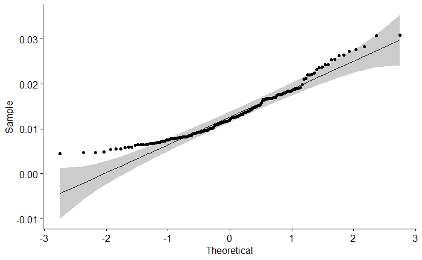

```r
ggqqplot(ParsiDF$MaxInterpenetration)
```

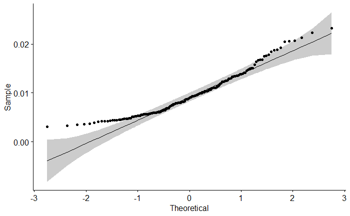

```r
ggqqplot(ParsiDF$AverageInterpenetration)
```

```r
ParsiDF %>%
  group_by(InterpenetrationFeedback, Part) %>%
  shapiro_test(MaxInterpenetration)
```

| InterpenetrationFeedback | Part | variable | statistic | p |
| --- | --- | --- | --- | --- |
| Both | Part 1 | MaxInterpenetration | 0.9463698 | 0.290340459 |
| Both | Part 2 | MaxInterpenetration | 0.8336128 | 0.002246291 |
| Electrotactile | Part 1 | MaxInterpenetration | 0.9674758 | 0.676776433 |
| Electrotactile | Part 2 | MaxInterpenetration | 0.8590639 | 0.006110260 |
| NoFeedback | Part 1 | MaxInterpenetration | 0.9694181 | 0.720117306 |
| NoFeedback | Part 2 | MaxInterpenetration | 0.9767405 | 0.872128294 |
| Visual | Part 1 | MaxInterpenetration | 0.8595117 | 0.006222341 |
| Visual | Part 2 | MaxInterpenetration | 0.8984690 | 0.032684820 |

```r
ParsiDF %>%
  group_by(InterpenetrationFeedback, Part) %>%
  shapiro_test(AverageInterpenetration)
```

| InterpenetrationFeedback | Part | variable | statistic | p |
| --- | --- | --- | --- | --- |
| Both | Part 1 | AverageInterpenetration | 0.9471955 | 0.301176358 |
| Both | Part 2 | AverageInterpenetration | 0.8270140 | 0.001750387 |
| Electrotactile | Part 1 | AverageInterpenetration | 0.9636280 | 0.591983751 |
| Electrotactile | Part 2 | AverageInterpenetration | 0.8768082 | 0.012752470 |
| NoFeedback | Part 1 | AverageInterpenetration | 0.9638882 | 0.597610313 |
| NoFeedback | Part 2 | AverageInterpenetration | 0.9549130 | 0.420117907 |
| Visual | Part 1 | AverageInterpenetration | 0.8511819 | 0.004451891 |
| Visual | Part 2 | AverageInterpenetration | 0.9138840 | 0.065545152 |

```r
ParsiDF$MaxInterpenetration <- log(ParsiDF$MaxInterpenetration)

ParsiDF$AverageInterpenetration <- log(ParsiDF$AverageInterpenetration)

shapiro_test(ParsiDF$MaxInterpenetration)
```

| variable | statistic | p.value |
| --- | --- | --- |
| ParsiDF$MaxInterpenetration | 0.9876969 | 0.1490966 |

```r
shapiro_test(ParsiDF$AverageInterpenetration)
```

| variable | statistic | p.value |
| --- | --- | --- |
| ParsiDF$AverageInterpenetration | 0.9858611 | 0.08731612 |

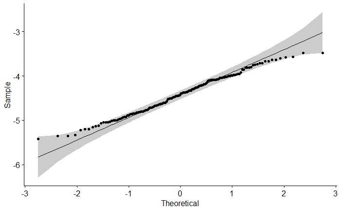

```r
ggqqplot(ParsiDF$MaxInterpenetration)
```

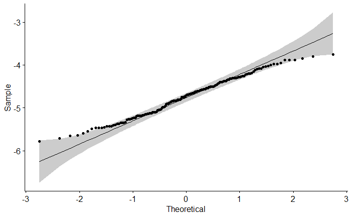

```r
ggqqplot(ParsiDF$AverageInterpenetration)
```

```r
#Let's check the assumption for each interpenetration feedback and shade condition
ParsiDF %>%
  group_by(InterpenetrationFeedback, Part) %>%
  shapiro_test(MaxInterpenetration)
```

| InterpenetrationFeedback | Part | variable | statistic | p |
| --- | --- | --- | --- | --- |
| Both | Part 1 | MaxInterpenetration | 0.9868279 | 0.9888746 |
| Both | Part 2 | MaxInterpenetration | 0.9661039 | 0.6462359 |
| Electrotactile | Part 1 | MaxInterpenetration | 0.9308313 | 0.1430371 |
| Electrotactile | Part 2 | MaxInterpenetration | 0.9745812 | 0.8307246 |
| NoFeedback | Part 1 | MaxInterpenetration | 0.9575452 | 0.4681252 |
| NoFeedback | Part 2 | MaxInterpenetration | 0.9507758 | 0.3523142 |
| Visual | Part 1 | MaxInterpenetration | 0.9631842 | 0.5824357 |
| Visual | Part 2 | MaxInterpenetration | 0.9755908 | 0.8505899 |

```r
ParsiDF %>%
  group_by(InterpenetrationFeedback, Part) %>%
  shapiro_test(AverageInterpenetration)
```

| InterpenetrationFeedback | Part | variable | statistic | p |
| --- | --- | --- | --- | --- |
| Both | Part 1 | AverageInterpenetration | 0.9757532 | 0.8537070 |
| Both | Part 2 | AverageInterpenetration | 0.9703017 | 0.7397138 |
| Electrotactile | Part 1 | AverageInterpenetration | 0.9535159 | 0.3961648 |
| Electrotactile | Part 2 | AverageInterpenetration | 0.9786997 | 0.9056434 |
| NoFeedback | Part 1 | AverageInterpenetration | 0.9556940 | 0.4339728 |
| NoFeedback | Part 2 | AverageInterpenetration | 0.9767880 | 0.8729898 |
| Visual | Part 1 | AverageInterpenetration | 0.9553767 | 0.4283032 |
| Visual | Part 2 | AverageInterpenetration | 0.9639963 | 0.5999528 |

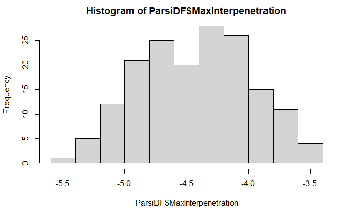

```r
hist(ParsiDF$MaxInterpenetration)
```

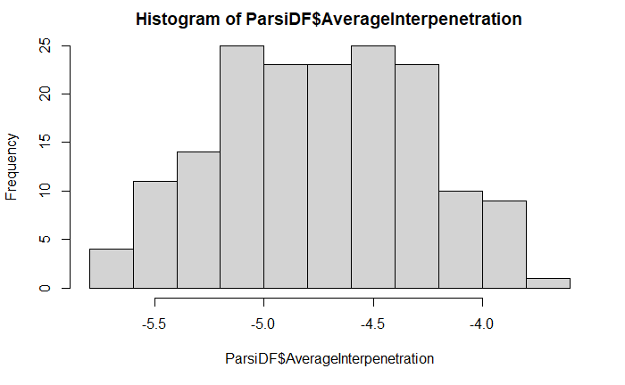

```r
hist(ParsiDF$AverageInterpenetration)
```

Good to go!

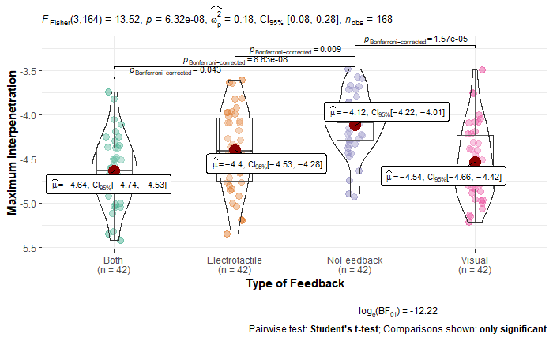

```r
p1 <- ggstatsplot::ggbetweenstats(
  data = ParsiDF,
  x = "InterpenetrationFeedback", #Indepedent Variable
  y = "MaxInterpenetration", # Depedent Variable
  grouping.var = "Part", # 2nd IV
  type = "p", # parametric test i.e., p values
  pairwise.comparisons = TRUE, #compute pairwise comparisons
  pairwise.display = "significant", # show only the significant ones
  p.adjust.method = "bonferroni", # correction of p-value
  effsize.type = "unbiased", # Calculates the Hedge's g for t tests and the partial Omega for ANOVA
  xlab = "Type of Feedback", #label of X axis
  ylab = "Maximum Interpenetration", #label of y axis
  var.equal = TRUE, #Assuming Equal variances
  mean.ci = TRUE, #display the confidence interval of the mean
  paired = TRUE #indicating that we have a within subject design
  )

p2 <- ggstatsplot::ggbetweenstats(
  data = ParsiDF,
  x = "InterpenetrationFeedback",
  y = "AverageInterpenetration",
  grouping.var = "Part",
  type = "p",
  pairwise.comparisons = TRUE,
  pairwise.display = "significant",
  p.adjust.method = "bonferroni",
  effsize.type = "unbiased",
  xlab = "Type of Feedback",
  ylab = "Average Interpenetration",
  var.equal = TRUE,
  mean.ci = TRUE,
  paired = TRUE
)


# Replicating the above but this time we look on the effect of the type of feedback on the DVs when the shaded is true and when it is false.
p3 <- ggstatsplot::grouped_ggbetweenstats(
  data = ParsiDF,
  x = "InterpenetrationFeedback",
  y = "MaxInterpenetration",
  grouping.var = "Part",
  type = "p",
  pairwise.comparisons = TRUE,
  pairwise.display = "significant",
  p.adjust.method = "bonferroni",
  effsize.type = "unbiased",
  xlab = "Type of Feedback",
  ylab = "Maximum Interpenetration",
  sub.text = "Explicit Visual Representation" ,
  var.equal = TRUE,
  mean.ci = TRUE,
  paired = TRUE
  )

p4 <- ggstatsplot::grouped_ggbetweenstats(
  data = ParsiDF,
  x = "InterpenetrationFeedback",
  y = "AverageInterpenetration",
  grouping.var = "Part",
  type = "p",
  pairwise.comparisons = TRUE,
  pairwise.display = "significant",
  p.adjust.method = "bonferroni",
  effsize.type = "unbiased",
  xlab = "Type of Feedback",
  ylab = "Average Interpenetration",
  var.equal = TRUE,
  mean.ci = TRUE,
  paired = TRUE
)

# Lets check the effect of shaded condition on DVs
p5 <- ggstatsplot:: ggbetweenstats(
  data = ParsiDF,
  x = "Part",
  y = "MaxInterpenetration",
  grouping.var = "InterpenetrationFeedback",
  type = "p",
  pairwise.comparisons = TRUE,
  pairwise.display = "significant",
  p.adjust.method = "bonferroni",
  effsize.type = "unbiased",
  xlab = "Target's Visual Representation",
  ylab = "Maximum Interpenetration",
  sub.text = "Explicit Visual Representation" ,
  var.equal = TRUE,
  mean.ci = TRUE,
  paired = TRUE
  )

p6 <- ggstatsplot::ggbetweenstats(
  data = ParsiDF,
  x = "Part",
  y = "AverageInterpenetration",
  grouping.var = "InterpenetrationFeedback",
  type = "p",
  pairwise.comparisons = TRUE,
  pairwise.display = "significant",
  p.adjust.method = "bonferroni",
  effsize.type = "unbiased",
  xlab = "Target's Visual Representation",
  ylab = "Average Interpenetration",
  var.equal = TRUE,
  mean.ci = TRUE,
  paired = TRUE
)

p7 <- ggstatsplot::grouped_ggbetweenstats(
  data = ParsiDF,
  x = "Part",
  y = "MaxInterpenetration",
  grouping.var = "InterpenetrationFeedback",
  type = "p",
  pairwise.comparisons = TRUE,
  pairwise.display = "significant",
  p.adjust.method = "bonferroni",
  effsize.type = "unbiased",
  xlab = "Target's Visual Representation",
  ylab = "Maximum Interpenetration",
  sub.text = "Explicit Visual Representation" ,
  var.equal = TRUE,
  mean.ci = TRUE,
  paired = TRUE
  )

p8 <- ggstatsplot::grouped_ggbetweenstats(
  data = ParsiDF,
  x = "Part",
  y = "AverageInterpenetration",
  grouping.var = "InterpenetrationFeedback",
  type = "p",
  pairwise.comparisons = TRUE,
  pairwise.display = "significant",
  p.adjust.method = "bonferroni",
  effsize.type = "unbiased",
  xlab = "Target's Visual Representation",
  ylab = "Average Interpenetration",
  var.equal = TRUE,
  mean.ci = TRUE,
  paired = TRUE
)
p1
```

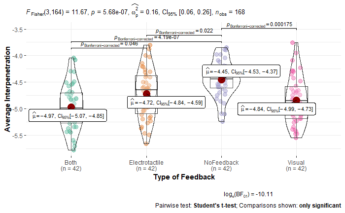

```r
p2
```

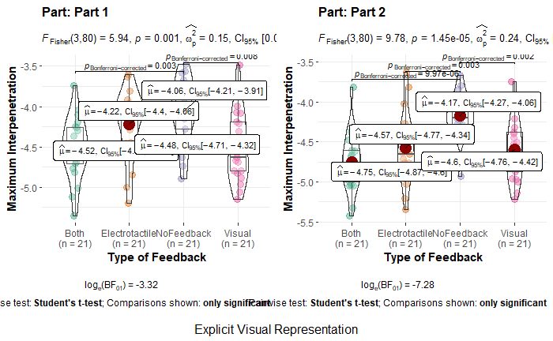

```r
p3
```

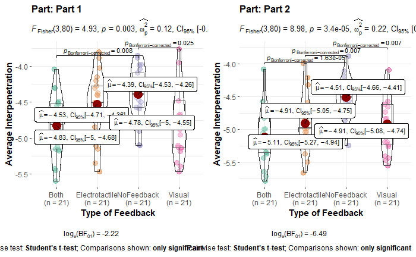

```r
p4
```

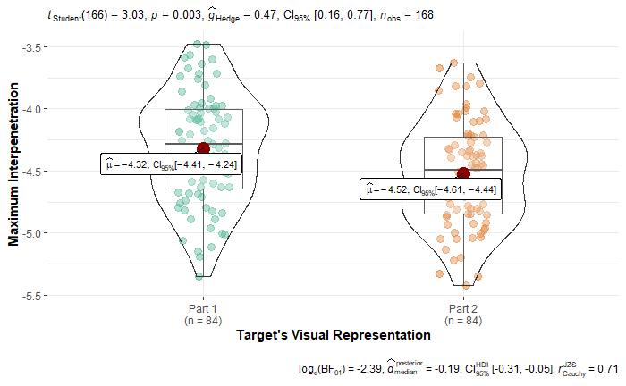

```r
p5
```

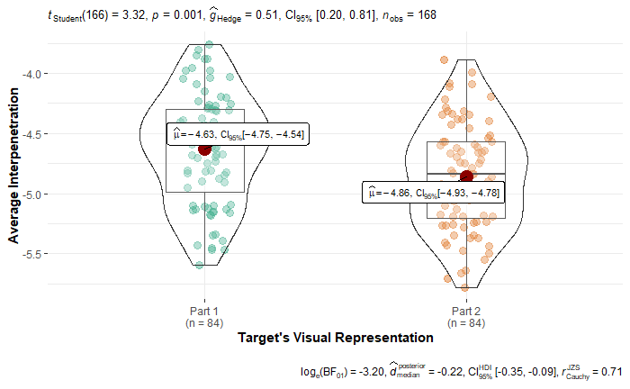

```r
p6
```

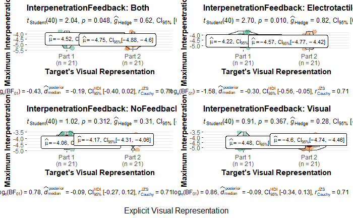

```r
p7
```

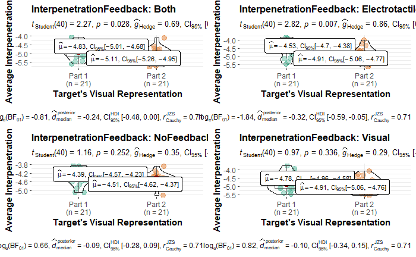

```r
p8
```

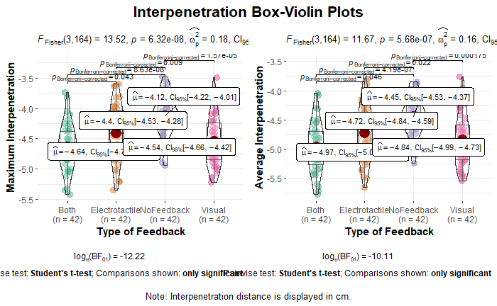

```r
plist <- list(p1,p2)
plist2 <- list(p3,p4)
plist3 <- list(p5,p6)
plist4 <- list(p7,p8)

combine_plots(
  plotlist = plist,
  title.text = "Interpenetration Box-Violin Plots",
  caption.text = "Note: Interpenetration distance is displayed in cm.",
  title.color = "black",
  caption.color = "black")
```

[figure not shown]

```r
combine_plots(
  plotlist = plist2,
  title.text = "Interpenetration Box-Violin Plots",
  caption.text = "Note: Interpenetration distance is displayed in cm.",
  title.color = "black",
  caption.color = "black")
```

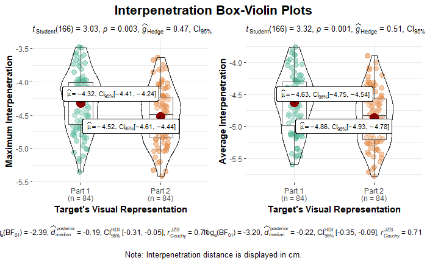

```r
combine_plots(
  plotlist = plist3,
  title.text = "Interpenetration Box-Violin Plots",
  caption.text = "Note: Interpenetration distance is displayed in cm.",
  title.color = "black",
  caption.color = "black")
```

[figure not shown]

```r
combine_plots(
  plotlist = plist4,
  title.text = "Interpenetration Box-Violin Plots",
  caption.text = "Note: Interpenetration distance is displayed in cm.",
  title.color = "black",
  caption.color = "black")
```

```r
NA
NA
NA
```

From the plots above we can see that #

1. there is not a significant difference between visual & electrotactile (plots 1-4).
2. the electrotactile becomes significant different from No Feedback in the 2nd part for both DVs (plots 3 & 4)
3. there in not a significant difference between electrotactile and both when we control for the parts of the experiment (plots 3 & 4)
4. the 2nd part is significant better than 1st part (Moderate Effect) (plots 5 & 6)
5. The type of interpenetration feedback has a large effect (based on Omega squared) on the DVs (plots 1-4), especially on the 2nd part of the experiment (plots 3 & 4)

Hedge’s G Interpretation: Small effect (cannot be discerned by the naked eye) = 0.2 Medium Effect = 0.5 Large Effect (can be seen by the naked eye) = 0.8

Reference for interpreting Omega Squared Small effect: ω2 = 0.01; Medium effect: ω2 = 0.06; Large effect: ω2 = 0.14.

Let’s check the Two Way Repeated Measures ANOVA

```r
aMax <- aov_ez("ID", "MaxInterpenetration", ParsiDF,
             within = c("Part", "InterpenetrationFeedback"),
             anova_table = list(es = "pes"))

knitr::kable(nice(aMax$anova_table))
```

| Effect | df | MSE | F | pes | p.value |
| --- | --- | --- | --- | --- | --- |
| Part | 1, 20 | 0.06 | 29.43 *** | .595 | <.001 |
| InterpenetrationFeedback | 1.88, 37.52 | 0.12 | 28.36 *** | .586 | <.001 |
| Part:InterpenetrationFeedback | 2.06, 41.24 | 0.04 | 5.16 ** | .205 | .009 |

```r
aAv <- aov_ez("ID", "AverageInterpenetration", ParsiDF,
             within = c("Part", "InterpenetrationFeedback"),
             anova_table = list(es = "pes"))

knitr::kable(nice(aAv$anova_table))
```

| Effect | df | MSE | F | pes | p.value |
| --- | --- | --- | --- | --- | --- |
| Part | 1, 20 | 0.07 | 31.74 *** | .613 | <.001 |
| InterpenetrationFeedback | 1.97, 39.31 | 0.12 | 25.89 *** | .564 | <.001 |
| Part:InterpenetrationFeedback | 2.11, 42.21 | 0.04 | 5.72 ** | .222 | .006 |

```r
effectsize::omega_squared(aMax, partial = TRUE, ci = 0.95)
```

```
Parameter                     | Omega2 (partial) |        95% CI
----------------------------------------------------------------
Part                          |             0.56 | [ 0.24, 0.74]
InterpenetrationFeedback      |             0.56 | [ 0.38, 0.68]
Part:InterpenetrationFeedback |             0.16 | [-0.02, 0.32]
```

```r
effectsize::omega_squared(aAv, partial = TRUE, ci = 0.95)
```

```
Parameter                     | Omega2 (partial) |        95% CI
----------------------------------------------------------------
Part                          |             0.58 | [ 0.26, 0.75]
InterpenetrationFeedback      |             0.54 | [ 0.35, 0.66]
Part:InterpenetrationFeedback |             0.18 | [-0.01, 0.34]
```

We can see that every type of feedback as well as the interrelationship with the part of the experiment have a large effect on DVs!!!!!!

Reference for interpreting Omega Squared Small effect: ω2 = 0.01; Medium effect: ω2 = 0.06; Large effect: ω2 = 0.14.

Let’s check the post hoc tests (Whole experiment)

```r
ParsiMax <- pairwise.t.test(ParsiDF$MaxInterpenetration, ParsiDF$InterpenetrationFeedback, p.adjust.method = "bonferroni",
        paired = TRUE, alternative = "two.sided")

ParsiAv <- pairwise.t.test(ParsiDF$AverageInterpenetration, ParsiDF$InterpenetrationFeedback, p.adjust.method = "bonferroni",
        paired = TRUE, alternative = "two.sided")

ParsiMax
```

```
    Pairwise comparisons using paired t tests

data:  ParsiDF$MaxInterpenetration and ParsiDF$InterpenetrationFeedback

               Both    Electrotactile NoFeedback
Electrotactile 2.8e-07 -              -
NoFeedback     2.6e-10 0.00015        -
Visual         0.05419 0.03766        5.2e-08

P value adjustment method: bonferroni
```

```r
ParsiAv
```

```
    Pairwise comparisons using paired t tests

data:  ParsiDF$AverageInterpenetration and ParsiDF$InterpenetrationFeedback

               Both    Electrotactile NoFeedback
Electrotactile 8.8e-07 -              -
NoFeedback     8.0e-10 0.00031        -
Visual         0.00862 0.11218        2.9e-07

P value adjustment method: bonferroni
```

For both DVs, we can see that there are significant differences between

Both and NoFeedback

Visual and NoFeedback

Electrotactile and NoFeedback

Both and Electrotactile

Let’s repeat the comparisons for each part of the experiment now.

Preparation of data for multiple comparisons (In Part1, Part2), t tests, and effect sizes based on Hedge’s g (the best one for small sample sizes like this one)

```r
# Divide the data
Data_1st <- subset(ParsiDF, Part = "1st Part", select = c(ID, InterpenetrationFeedback, MaxInterpenetration, AverageInterpenetration))
Data_2nd <- subset(ParsiDF, Part = "2nd Part", select = c(ID, InterpenetrationFeedback, MaxInterpenetration, AverageInterpenetration))

#Covert the logs back to normal numbers, because we dont care here for the normal distribution

Data_1st$MaxInterpenetration <- exp(Data_1st$MaxInterpenetration)
Data_1st$AverageInterpenetration <- exp(Data_1st$AverageInterpenetration)

Data_2nd$MaxInterpenetration <- exp(Data_2nd$MaxInterpenetration)
Data_2nd$AverageInterpenetration <- exp(Data_2nd$AverageInterpenetration)
##### Divide Further the data per interpenetration feedback

B1 <- filter(Data_1st, InterpenetrationFeedback == "Both")

El1 <-filter(Data_1st, InterpenetrationFeedback == "Electrotactile")

No1 <- filter(Data_1st, InterpenetrationFeedback == "NoFeedback")

V1 <- filter(Data_1st, InterpenetrationFeedback == "Visual")

B2 <- filter(Data_2nd, InterpenetrationFeedback == "Both")

El2 <-filter(Data_2nd, InterpenetrationFeedback == "Electrotactile")

No2 <- filter(Data_2nd, InterpenetrationFeedback == "NoFeedback")

V2 <- filter(Data_2nd, InterpenetrationFeedback == "Visual")


#Merge them back together to create two versions (part 1 = .x, part 2 = .y) for each DV.
Rm1 <- merge(B1,B2, by = c("ID", "InterpenetrationFeedback"))
Rm2 <- merge(El1,El2, by = c("ID", "InterpenetrationFeedback"))
Rm3 <- merge(No1, No2, by = c("ID", "InterpenetrationFeedback"))
Rm4 <- merge(V1,V2, by = c("ID", "InterpenetrationFeedback"))
```

```r
ParsiMax1 <- pairwise.t.test(Data_1st$MaxInterpenetration, Data_1st$InterpenetrationFeedback, p.adjust.method = "bonferroni",
        paired = FALSE, alternative = "two.sided")

ParsiAv1 <- pairwise.t.test(Data_1st$AverageInterpenetration, Data_1st$InterpenetrationFeedback, p.adjust.method = "bonferroni",
        paired = FALSE, alternative = "two.sided")

ParsiMax2 <- pairwise.t.test(Data_2nd$MaxInterpenetration, Data_2nd$InterpenetrationFeedback, p.adjust.method = "bonferroni",
        paired = FALSE, alternative = "two.sided")

ParsiAv2 <- pairwise.t.test(Data_2nd$AverageInterpenetration, Data_2nd$InterpenetrationFeedback, p.adjust.method = "bonferroni",
        paired = FALSE, alternative = "two.sided")

ParsiMax1
```

```
    Pairwise comparisons using t tests with pooled SD

data:  Data_1st$MaxInterpenetration and Data_1st$InterpenetrationFeedback

               Both    Electrotactile NoFeedback
Electrotactile 0.048   -              -
NoFeedback     1.9e-07 0.012          -
Visual         1.000   0.637          2.6e-05

P value adjustment method: bonferroni
```

```r
ParsiAv1
```

```
    Pairwise comparisons using t tests with pooled SD

data:  Data_1st$AverageInterpenetration and Data_1st$InterpenetrationFeedback

               Both    Electrotactile NoFeedback
Electrotactile 0.06941 -              -
NoFeedback     3e-06   0.04821        -
Visual         1.00000 1.00000        0.00058

P value adjustment method: bonferroni
```

```r
ParsiMax2
```

```
    Pairwise comparisons using t tests with pooled SD

data:  Data_2nd$MaxInterpenetration and Data_2nd$InterpenetrationFeedback

               Both    Electrotactile NoFeedback
Electrotactile 0.048   -              -
NoFeedback     1.9e-07 0.012          -
Visual         1.000   0.637          2.6e-05

P value adjustment method: bonferroni
```

```r
ParsiAv2
```

```
    Pairwise comparisons using t tests with pooled SD

data:  Data_2nd$AverageInterpenetration and Data_2nd$InterpenetrationFeedback

               Both    Electrotactile NoFeedback
Electrotactile 0.06941 -              -
NoFeedback     3e-06   0.04821        -
Visual         1.00000 1.00000        0.00058

P value adjustment method: bonferroni
```